# Multiple instance based deep classification for mass spectrometry imaging

Dan Guo & Sai Srikanth Lakkimsetty

1/29/2023

# 1 Introduction

In case study 4, we apply a special classification to classify tumor and stromal spectra of 39 bladder tumor and benign tissue cores (same dataset as in case study 3). We make use of *CardinalNN*, which is a package of *Cardinal* family. It provides the multiple-instance convolutional neural network [mi-CNN](https://doi.org/10.1093/bioinformatics/btaa436) method, which allows both semi-supervised and fully-supervised deep learning methods for tissue classification for two classes using Mass Spectrometry Imaging (MSI) data. The neural network used as classifier is convolutional neural network (CNN).

- *Fully supervised*. It is the same as standard supervised classification and it is used when the ground-truth labels of pixels are known.
- *Multiple instance*. It is semi-supervised classification and it is used when only the ground-truth labels of tissues are known while no labels for pixels. The assumption is that positive tissues can contain both positive and negative pixels, while negative tissues can only contain negative pixels.

# 2 Installation

The methods in *CardinalNN* are implemented in R but the deep learning methods are available in Python. The deep learning methods are distributed through the *DeepMSI* python package. As such, CadinalNN uses the implementation in Python but the user does not need any knowledge of Python. It is fully executed from within R. However, both Python and a few packages need to be installed and are described below.

NOTE: The below steps (2.1 and 2.2) are essential for successful installation of *CardinalNN* and *DeepMSI* packages.

## 2.1 Installation of R-based software

*CardinalNN* can be installed through [GitHub](https://github.com/DanGuo1223/CardinalNN) using `devtools`.

```r
if (!require("devtools", quietly = TRUE))
    install.packages("devtools")
devtools::install_github("https://github.com/DanGuo1223/CardinalNN")
```

*CardinalNN* will also be distributed through the [Bioconductor](https://bioconductor.org) project in the future and could be installed as below.

```r
install.packages("BiocManager")
BiocManager::install(version="devel")
BiocManager::install("CardinalNN")
```

The same function can be used to update *CardinalNN* and other Bioconductor packages.

Once installed, *CardinalNN* can be loaded with `library()`. We import `reticulate` package to execute python code from within R.

```r
library("CardinalNN")
library("reticulate")
```

## 2.2 Installation of Python-based software

1. **Download Python**: If you already have python installed, skip this step. Download python3 from [this download link](https://www.python.org/downloads/) and follow the instructions. If you are on a Windows machine, depending upon your OS version, you should select the appropriate Python version to download.
   - Windows 8 and later: you can install the latest stable release.
   - Windows XP through Windows 7: the latest version you can install is Python 3.8.10. You may also install python using `reticulate`: `reticulate::install_python(version="3.8.10")`
2. Setup virtual environment for python.
   - If you are on a Mac or Linux computer,
     - Open the terminal app ([MacOS help](https://support.apple.com/guide/terminal/open-or-quit-terminal-apd5265185d-f365-44cb-8b09-71a064a42125/mac)) and navigate to Documents folder, use `cd ~/Documents/`.
     - Create a virtual environment: `python3 -m venv --name deepmsi`
     - Activate the virtual environment: `source deepmsi/bin/activate`
     - To deactivate the virtual environment later: `deactivate`
   - If you are on Windows computer,
     - Open the terminal app ([Windows help](https://docs.microsoft.com/en-us/windows/terminal/install#invoke-the-command-palette)) and run cmd.exe and navigate to the Documents directory, `~\Documents`, use the command `cd Documents\` and hit enter).
     - Create a virtual environment: `c:\PythonXX\python -m venv c:~\Documents\deepmsi`, where `XX` is the version of python you are using or installed as above.
     - Activate the virtual environment `deepmsi/Scripts/activate`
3. Download `DeepMSI` package from GitHub and install the package.
   - Go to this [GitHub repository](https://github.com/DanGuo1223/DeepMSI/) and click on the drop down menu **Code** in green color. Select **Download ZIP** to download the package.
   - Go to your Downloads folder and extract the downloaded files from the zip file (DeepMSI.zip).
   - If you are on a Mac or Linux computer,
     - Open the terminal app ([MacOS help](https://support.apple.com/guide/terminal/open-or-quit-terminal-apd5265185d-f365-44cb-8b09-71a064a42125/mac)) and navigate to the extracted folder directory using `cd` (for example, if your downloads folder is `~/Downloads`, use the command `cd ~/Downloads/DeepMSI/`).
     - Install the package using `sudo python3 setup.py install` (if you do not have sudo privilages for the computer, please contact your adminstrator).
   - If you are on a Windows computer,
     - Open the terminal app ([Windows help](https://docs.microsoft.com/en-us/windows/terminal/install#invoke-the-command-palette)) and run cmd.exe and navigate to the extracted folder directory using `cd` (for example, if your downloads folder is `~\Downloads`, use the command `cd Downloads\DeepMSI-main` and hit enter).
     - Install the package by copying `py setup.py install` into the terminal and hit enter.

# 3 Load and prepare the datasets

We use the same dataset as in case study 3. The data files are made available through *massive.quant*. The links for datasets are [TMA1](https://massive.ucsd.edu/ProteoSAFe/DownloadResultFile?file=f.RMSV000000686/2023-02-06_MCFoell_6554995d/other/TMA1_preprocessed.RData) and [TMA2](https://massive.ucsd.edu/ProteoSAFe/DownloadResultFile?file=f.RMSV000000686/2023-02-06_MCFoell_6554995d/other/TMA2_preprocessed.RData). If you would like to preview the data before downloading, please visit this [link](https://massive.ucsd.edu/ProteoSAFe/dataset_files.jsp?task=9d66bf96de29438cafbad5a3e6634a0b#%7B%22table_sort_history%22%3A%22main.collection_asc%22%7D). To focus on the classification methods, we import the pre-processed files that we saved in case study 3.

```r
load(file.path(data_path, "TMA1_preprocessed.RData"))
load(file.path(data_path, "TMA2_preprocessed.RData"))
```

By exporting the data as .RData object we have the advantage that all the metadata are still linked to each spectrum. We have a look at the metadata to remind us about them.

```r
pData(TMA1_normalized)
```

```
## PositionDataFrame with 1052 rows and 4 columns
##         :run:   coord:x   coord:y   histology    diagnosis invasiveness     patient
##      <factor> <integer> <integer> <character>  <character>  <character> <character>
## 1        TMA1        71         7       Tumor infiltrating infiltrating   patient15
## 2        TMA1        72         7       Tumor infiltrating infiltrating   patient15
## 3        TMA1        67         8       Tumor infiltrating infiltrating   patient15
## 4        TMA1        68         8       Tumor infiltrating infiltrating   patient15
## 5        TMA1        69         8       Tumor infiltrating infiltrating   patient15
## ...       ...       ...       ...         ...          ...          ...         ...
## 1048     TMA1        53       108      Stroma infiltrating infiltrating    patient6
## 1049     TMA1        50       109      Stroma infiltrating infiltrating    patient6
## 1050     TMA1        51       109      Stroma infiltrating infiltrating    patient6
## 1051     TMA1        52       109      Stroma infiltrating infiltrating    patient6
## 1052     TMA1        53       109      Stroma infiltrating infiltrating    patient6
```

```r
pData(TMA2_normalized)
```

```
## PositionDataFrame with 1117 rows and 4 columns
##         :run:   coord:x   coord:y   histology    diagnosis     invasiveness     patient
##      <factor> <integer> <integer> <character>  <character>      <character> <character>
## 1        TMA2       111         8      Stroma       benign               NA   patient39
## 2        TMA2        87         9       Tumor infiltrating     infiltrating   patient34
## 3        TMA2        88         9       Tumor infiltrating     infiltrating   patient34
## 4        TMA2        89         9       Tumor infiltrating     infiltrating   patient34
## 5        TMA2        90         9       Tumor infiltrating     infiltrating   patient34
## ...       ...       ...       ...         ...          ...              ...         ...
## 1113     TMA2       125       118       Tumor          low non-infiltrating   patient40
## 1114     TMA2       126       118       Tumor          low non-infiltrating   patient40
## 1115     TMA2       123       119       Tumor          low non-infiltrating   patient40
## 1116     TMA2       124       119       Tumor          low non-infiltrating   patient40
## 1117     TMA2       125       119       Tumor          low non-infiltrating   patient40
```

The histology refers to the tissue type, which is either tumor or stroma. The diagnosis contains the diagnosis of the patient from which the tissue is derived. It can be a cancer subtype (infiltrating, low-grade, high-grade) or benign (healthy). Invasiveness distinguishs the muscle infiltrating cancer subtype from the non-muscle infiltrating ones (low-grade, high-grade) but is not further used in this vignette.

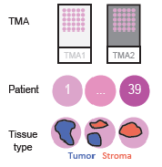

Overview of the dataset

The advantage of this dataset is that each tissue core is not only described by the diagnosis (tissue level annotation) but also the tissue type (histology) of smaller tissue areas with cancer and stromal tissues (subtissue level annotation) were annotated by a pathologist. Thus we will perform two different classifications: 1) fully supervised classification using the subtissue level annotation (plabel), and 2) semi-supervised classification based on the tissue level annotations (tlabel). For an easier data handling we will rename the ‘diagnosis’ to ‘tlabel’ and ‘histology’ to ‘plabel’ and ‘patient’ to ‘sample’. We will use TMA2 as the training set and TMA1 as the testing dataset, therefore we also rename them accordingly. In our model, we label (`plabel`) stroma to be group `0` and cancer to be group `1`.

```r
#TMA2

colnames(pData(TMA2_normalized))[colnames(pData(TMA2_normalized))=="histology"] <- "plabel"
colnames(pData(TMA2_normalized))[colnames(pData(TMA2_normalized))=="patient"] <- "sample"

mse_train <- TMA2_normalized

mse_train$plabel = ifelse(mse_train$plabel == 'Tumor', 1, 0)
mse_train$tlabel = rep(0, length(mse_train))
for (s in unique(mse_train$sample))
{
  if (sum(mse_train$plabel[mse_train$sample == s]) > 0)
  {
    mse_train$tlabel[mse_train$sample == s] = 1
  }
}

#TMA1

colnames(pData(TMA1_normalized))[colnames(pData(TMA1_normalized))=="histology"] <- "plabel"
colnames(pData(TMA1_normalized))[colnames(pData(TMA1_normalized))=="patient"] <- "sample"

mse_test <- TMA1_normalized

mse_test$plabel = ifelse(mse_test$plabel == 'Tumor', 1, 0)
mse_test$tlabel = rep(0, length(mse_test))
for (s in unique(mse_test$sample))
{
  if (sum(mse_test$plabel[mse_test$sample == s]) > 0)
  {
    mse_test$tlabel[mse_test$sample == s] = 1
  }
}
```